# ch03_05_03_비지도학습_얼굴데이터셋분석_v11_2610

📚 참고: 이 실습은 『파이썬 라이브러리를 활용한 머신러닝』(안드레아스 뮐러·세라 가이도 지음, 박해선 옮김, 한빛미디어) 예제와 저자의 `mglearn` 패키지(BSD 라이선스)를 바탕으로 합니다.

> 🛠️ **2026.10 수정본 (v11)** — 원본: ch03_05_03_비지도학습_얼굴데이터셋분석.ipynb

> 최신 scikit-learn은 `pca.inverse_transform()`에 1차원 배열(중심점 하나)을 넣으면 에러를 내요. `center.reshape(1, -1)`로 2차원으로 바꿔 넣고, 같은 호출을 내부에서 하는 `mglearn.plots.plot_kmeans_faces`에는 2차원으로 바꿔 주는 작은 껍데기(`PCA2D`)를 넘기도록 했습니다. KMeans는 scikit-learn 1.4부터 기본 시도 횟수가 줄어서 `n_init=10`을 적어 예전과 같은 방식으로 돌렸어요.

### 얼굴 데이터 셋으로 군집 알고리즘 비교

### 학습 내용

```python
import matplotlib.pyplot as plt
import numpy as np
```

```python
from sklearn.model_selection import train_test_split
from sklearn.decomposition import NMF
from sklearn.cluster import DBSCAN
from sklearn.decomposition import PCA
```

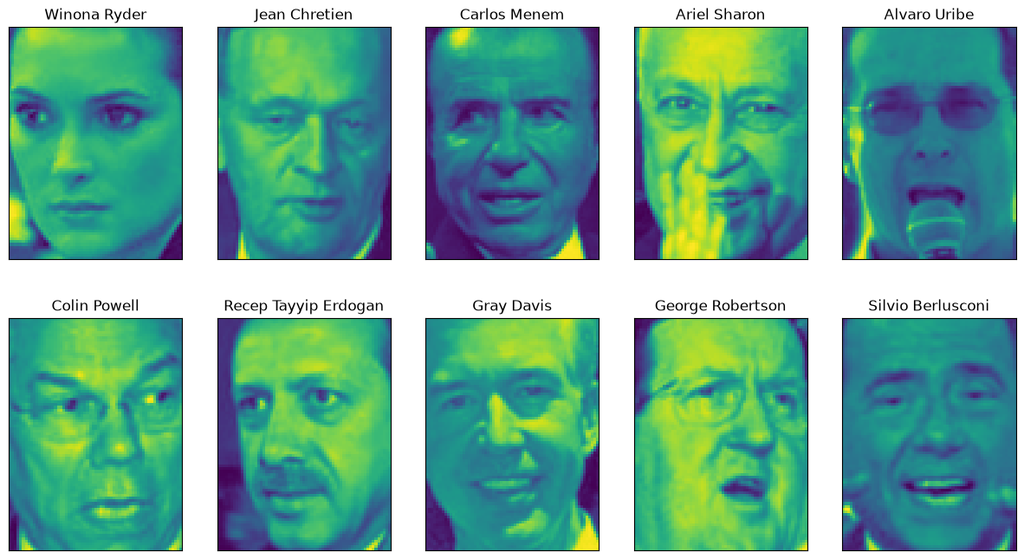

```python
from sklearn.datasets import fetch_lfw_people
people = fetch_lfw_people(min_faces_per_person=20, resize=0.7)
image_shape = people.images[0].shape

fig, axes = plt.subplots(2, 5, figsize=(15, 8),
                         subplot_kw={'xticks': (), 'yticks': ()})
for target, image, ax in zip(people.target, people.images, axes.ravel()):
    ax.imshow(image)
    ax.set_title(people.target_names[target])
```

```python
mask = np.zeros(people.target.shape, dtype=np.bool)
for target in np.unique(people.target):
    mask[np.where(people.target == target)[0][:50]] = 1

X_people = people.data[mask]
y_people = people.target[mask]

# 0~255 사이의 흑백 이미지의 픽셀 값을 0~1 사이로 스케일 조정합니다.
# (옮긴이) MinMaxScaler를 적용하는 것과 거의 동일합니다.
X_people = X_people / 255.
```

### PCA 주성분 분석

```python
# LFW 데이터에서 고유얼굴을 찾은 다음 데이터를 변환합니다
from sklearn.decomposition import PCA
pca = PCA(n_components=100, whiten=True, random_state=0)
pca.fit_transform(X_people)
X_pca = pca.transform(X_people)
```

### DBSCAN

```python
# 기본 매개변수로 DBSCAN을 적용합니다
dbscan = DBSCAN()
labels = dbscan.fit_predict(X_pca)
print("고유한 레이블: {}".format(np.unique(labels)))
```

```
고유한 레이블: [-1]
```

- 레이블이 -1이므로 모든 데이터가 DBSCAN에 의해 잡음 포인트로 레이블됨.
  - 해결 : eps값을 크게 하거나, min_samples값을 낮추기

```python
dbscan = DBSCAN(min_samples=3)
labels = dbscan.fit_predict(X_pca)
print("고유한 레이블: {}".format(np.unique(labels)))
```

```
고유한 레이블: [-1]
```

- eps 값을 키워보기

```python
dbscan = DBSCAN(min_samples=3, eps=15)
labels = dbscan.fit_predict(X_pca)
print("고유한 레이블: {}".format(np.unique(labels)))
```

```
고유한 레이블: [-1  0]
```

### 잡음 포인트와 클러스터 포인트 확인하기

```python
# bincount는 음수를 받을 수 없어서 labels에 1을 더했습니다.
# 반환값의 첫 번째 원소는 잡음 포인트의 수입니다.
print("클러스터별 포인트 수: {}".format(np.bincount(labels + 1)))
```

```
클러스터별 포인트 수: [  37 2026]
```

### 어떤 것이 잡음 포인트일까?

[figure not shown]

```python
noise = X_people[labels==-1]

fig, axes = plt.subplots(3, 9,
                         subplot_kw={'xticks': (), 'yticks': ()},
                         figsize=(12, 4))

for image, ax in zip(noise, axes.ravel()):
    ax.imshow(image.reshape(image_shape), vmin=0, vmax=1)
```

#### 이와 같이 특이한 것을 찾아내는 것을 이상치 검출(outlier detection)이라 한다.

- 실제 애플리케이션이라면 이미지 여백을 잘라 일정한 데이터 셋을 만드는 것이 좋음.
- 큰 클러스터 하나보다 더 많은 클러스터를 찾으려면 eps를 0.5(기본값) ~ 15 사이 정도로 줄여야 함.

### eps에 따른 클러스터 수의 크기와 크기

```python
for eps in [1,3,5,7,9,11,13]:
    print("\n eps = ", eps)
    dbscan = DBSCAN(eps =  eps, min_samples=3)
    labels = dbscan.fit_predict(X_pca)
    print("클러스터 수 : ", len(np.unique(labels)))
    print("클러스터 크기 : ", np.bincount(labels + 1))
```

```
 eps =  1
클러스터 수 :  1
클러스터 크기 :  [2063]

 eps =  3
클러스터 수 :  1
클러스터 크기 :  [2063]

 eps =  5
클러스터 수 :  2
클러스터 크기 :  [2059    4]

 eps =  7
클러스터 수 :  8
클러스터 크기 :  [1954   75    4   14    6    4    3    3]

 eps =  9
클러스터 수 :  3
클러스터 크기 :  [1199  861    3]

 eps =  11
클러스터 수 :  2
클러스터 크기 :  [ 403 1660]

 eps =  13
클러스터 수 :  2
클러스터 크기 :  [ 119 1944]
```

- 큰 클러스터가 하나 있고, 그 이외에는 작은 클러스터
  - 확연히 구별되는 얼굴 이미지가 두 세 개가 아닌 모든 이미지는 거의 동일하게 나머지 이미지들과 비슷(또는 비슷하지 않음)것을 의미

### 작은 클러스터가 많이 만들어진 eps=7, min_samples=3의 결과 확인

```python
X_pca.shape
```

```
(2063, 100)
```

```python
dbscan = DBSCAN(eps =  7, min_samples=3)
labels = dbscan.fit_predict(X_pca)
np.unique(labels)
```

```
array([-1,  0,  1,  2,  3,  4,  5,  6])
```

[figure not shown]

[figure not shown]

[figure not shown]

[figure not shown]

[figure not shown]

[figure not shown]

[figure not shown]

```python
# labels : 만들어진 그룹

for cluster in range(max(labels) + 1):
    mask = labels == cluster
    n_images =  np.sum(mask)
    fig, axes = plt.subplots(1, 14, figsize=(14*1.5, 4),
                             subplot_kw={'xticks': (), 'yticks': ()})
    i = 0

    for image, label, ax in zip(X_people[mask], y_people[mask], axes):
        ax.imshow(image.reshape(image_shape), vmin=0, vmax=1)
        ax.set_title(people.target_names[label].split()[-1])
        i += 1

    for j in range(len(axes) - i):
        axes[j+i].imshow(np.array([[1]*65]*87), vmin=0, vmax=1)
        axes[j+i].axis('off')
```

### k-평균으로 얼굴 데이터 분석

- DBSCAN에서는 하나의 큰 클러스터 외에는 만들 수 없음.
- 병합군집과 K-means은 비슷한 크기의 클러스터를 만들 수 있음.

```python
from sklearn.cluster import KMeans
```

```python
# k-평균으로 클러스터를 추출합니다
km = KMeans(n_clusters=10, random_state=0, n_init=10)  # 2026.10 수정: scikit-learn 1.4부터 n_init 기본값이 10→'auto'(1번)로 바뀌어 예전처럼 10번 시도
labels_km = km.fit_predict(X_pca)
print("k-평균의 클러스터 크기: {}".format(np.bincount(labels_km)))
```

```
k-평균의 클러스터 크기: [122 286 202 220  60 327 363  80 205 198]
```

[figure not shown]

```python
fig, axes = plt.subplots(2, 5,
                         subplot_kw={'xticks': (), 'yticks': ()},
                         figsize=(12, 4))

for center, ax in zip(km.cluster_centers_, axes.ravel()):
    ax.imshow(pca.inverse_transform(center.reshape(1, -1)).reshape(image_shape),  # 2026.10 수정: 최신 scikit-learn은 inverse_transform에 2차원 배열(1행) 필요
              vmin=0, vmax=1)
```

### 각 클러스터에서 가장 대표 이미지(가장 가까운), 가장 동떨어진 이미지(중심에서 가장 먼 이미지) 다섯개

```python
import mglearn
```

[figure not shown]

```python
# 2026.10 수정: mglearn 내부가 pca.inverse_transform(1차원 배열)을 호출하는데, 최신 scikit-learn은 2차원만 받음 → 2차원으로 바꿔 주는 껍데기로 감싸서 전달
class PCA2D:
    def __init__(self, pca): self.pca = pca
    def inverse_transform(self, X): return self.pca.inverse_transform(np.atleast_2d(X))

mglearn.plots.plot_kmeans_faces(km, PCA2D(pca), X_pca, X_people,
                                y_people, people.target_names)
```